### Shade versus Sun leaves

This set of figures attempts to show that sun and shade leaves were different on multiple levels.

- ACI curves were measured at saturating light for both sun and shade leaves.

Leaf Biochemistry

| Leaf | Temperature | Vcmax | Vcmax_se | Jmax | Jmax_se |
| --- | --- | --- | --- | --- | --- |
| shade | ambient | 73 | 6.4 | 102 | 6.9 |
| shade | elevated | 78 | 4.9 | 106 | 6.5 |
| sun | ambient | 93 | 6.2 | 138 | 7.4 |
| sun | elevated | 88 | 9.1 | 140 | 13 |

- Here are some predicted ACI curves for sun/shade with temperature treatements. Both Vcmax and Jmax are reduced in shade leaves with little effect of treatment. Aci curves were only taken once towards the end of the experiment on well watered trees.

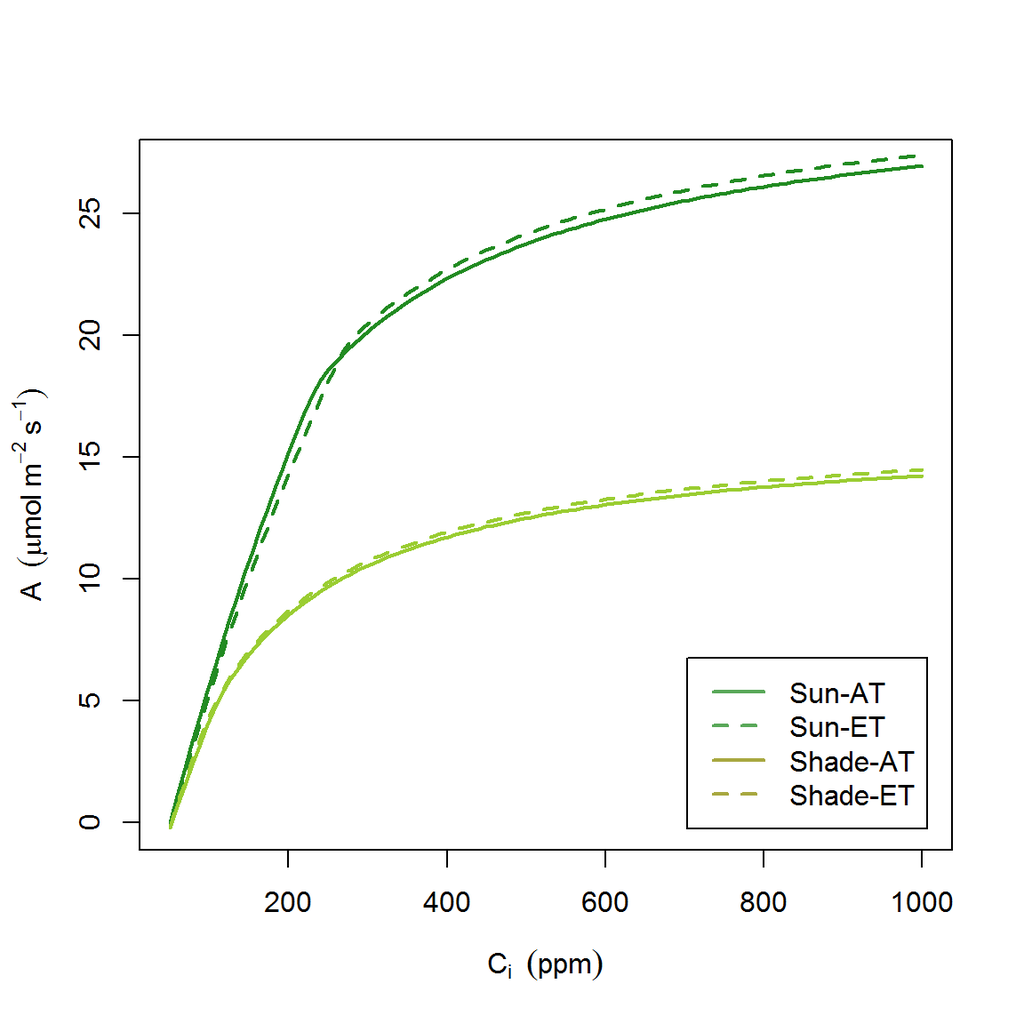

- This figure shows the relationship between leaf N on an area basis and carbon isotope dicrimination between leaf types.

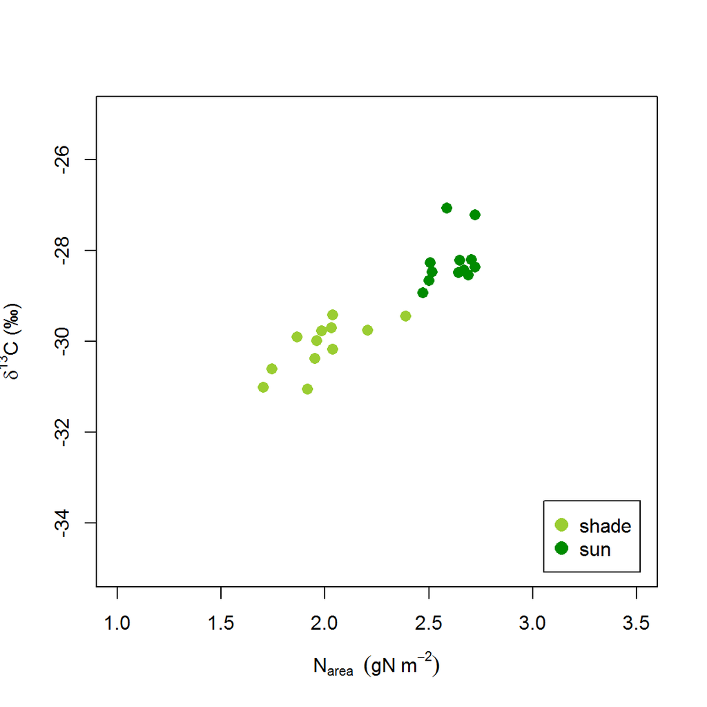

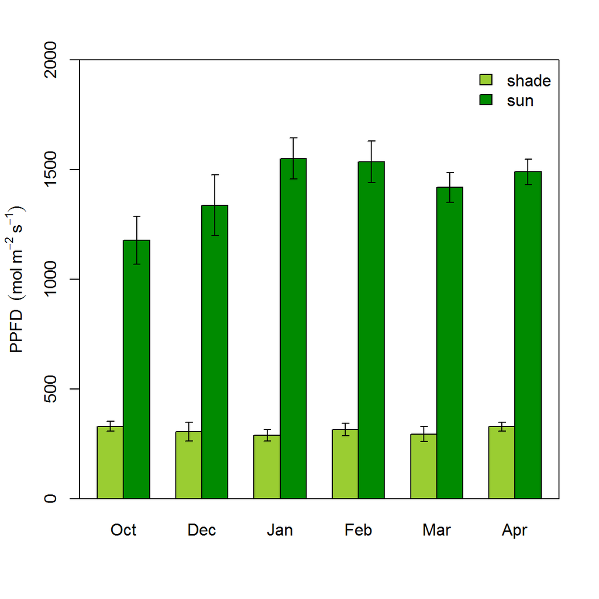

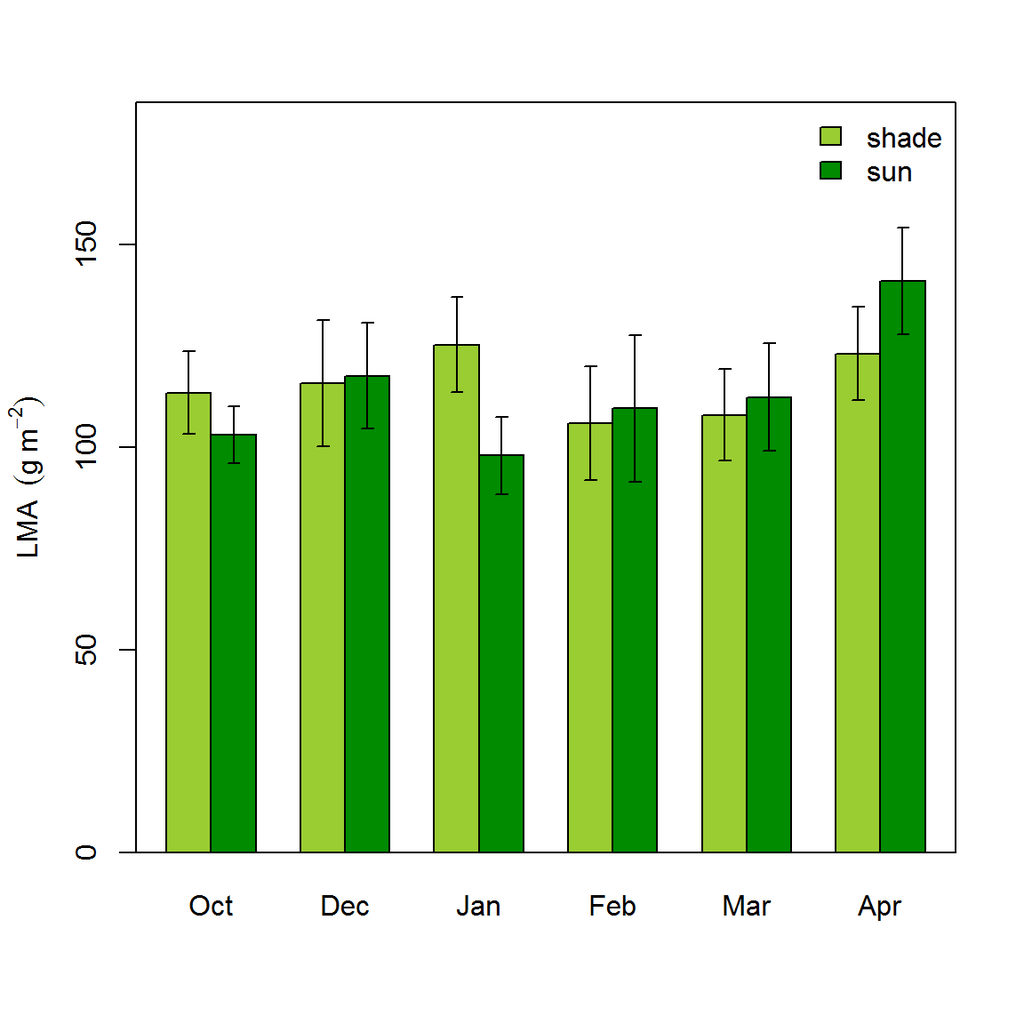

## Mesophyll Conducatnce

- Below are means and standard errors of gm across all campaigns.
- We took leaf measurements at their current temperature (ambient, +3) in order to do paired comparisons across leaves at a large range of temperatures. Im working on the paired comparisons now, but for this we will just focus on overall differences between leaf types.
- Further analysis is thus needed to tease apart any effects of temperature treatment as these are just the overall means over the 6 campaigns

#### gm by leaf type and light environment

- Gm was calculated with Rd and Gstar generated for E.globulus. Kristine Crous and I have compared tobacco with globulus calculations on FACE trees and they tend to lower the values of gm and generate less variance within a sample. I can easily alter the code to generate values with tobacco parameters if needed.
- Here i seperated the well watered treatment from the drought treatment. Im much more confident in the well watered trees as I was often on the border with drawdown and xsi for droughted leave. They do so similar patterns
- Shade gm is always lower than sun leaves but when the lights are turned on they have in instantenous response in gm that resembles sun leaves

Well Watered

| Leaf Type | Light | Temperature | leaflight | Gm | Gm(se) |
| --- | --- | --- | --- | --- | --- |
| shade | high | ambient | shade-high | 0.184 | 0.00345 |
| shade | high | elevated | shade-high | 0.177 | 0.00322 |
| shade | low | ambient | shade-low | 0.117 | 0.00359 |
| shade | low | elevated | shade-low | 0.116 | 0.00382 |
| sun | high | ambient | sun-high | 0.163 | 0.00481 |
| sun | high | elevated | sun-high | 0.153 | 0.00678 |

Drought

| Leaf Type | Light | Temperature | Leaf-Light | Gm | Gm(se) |
| --- | --- | --- | --- | --- | --- |
| shade | high | ambient | shade-high | 0.195 | 0.0124 |
| shade | high | elevated | shade-high | 0.152 | 0.00464 |
| shade | low | ambient | shade-low | 0.142 | 0.012 |
| shade | low | elevated | shade-low | 0.127 | 0.011 |
| sun | high | ambient | sun-high | 0.201 | 0.0104 |
| sun | high | elevated | sun-high | 0.219 | 0.0243 |

- Next, Ill just show means of sun and shade leaf physiology and keep it simple by ignoring the temperature treatment. We can address that later.

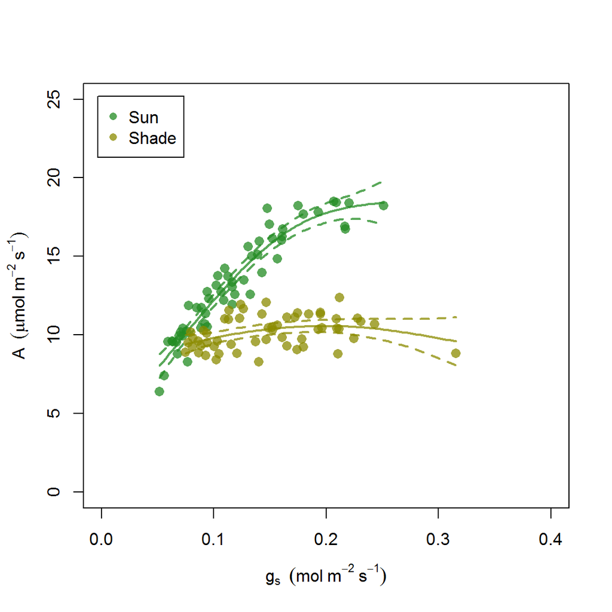

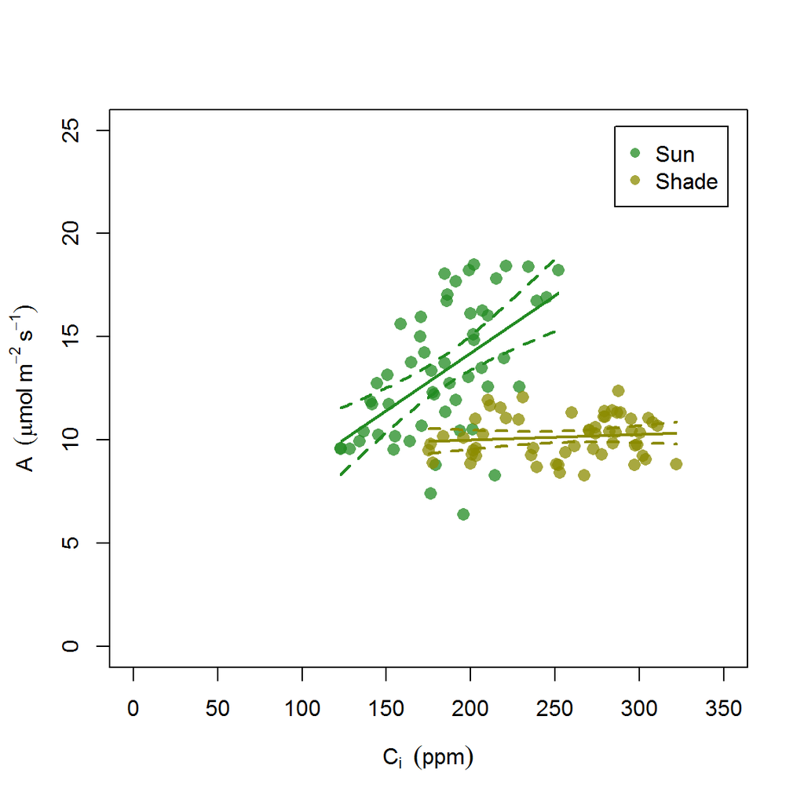

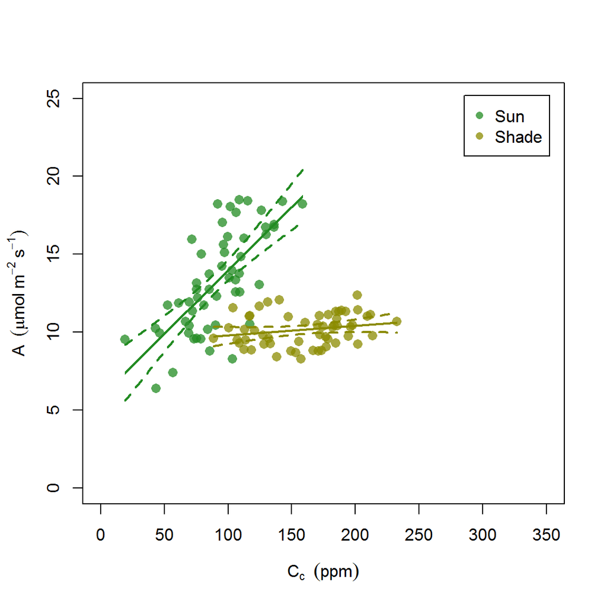

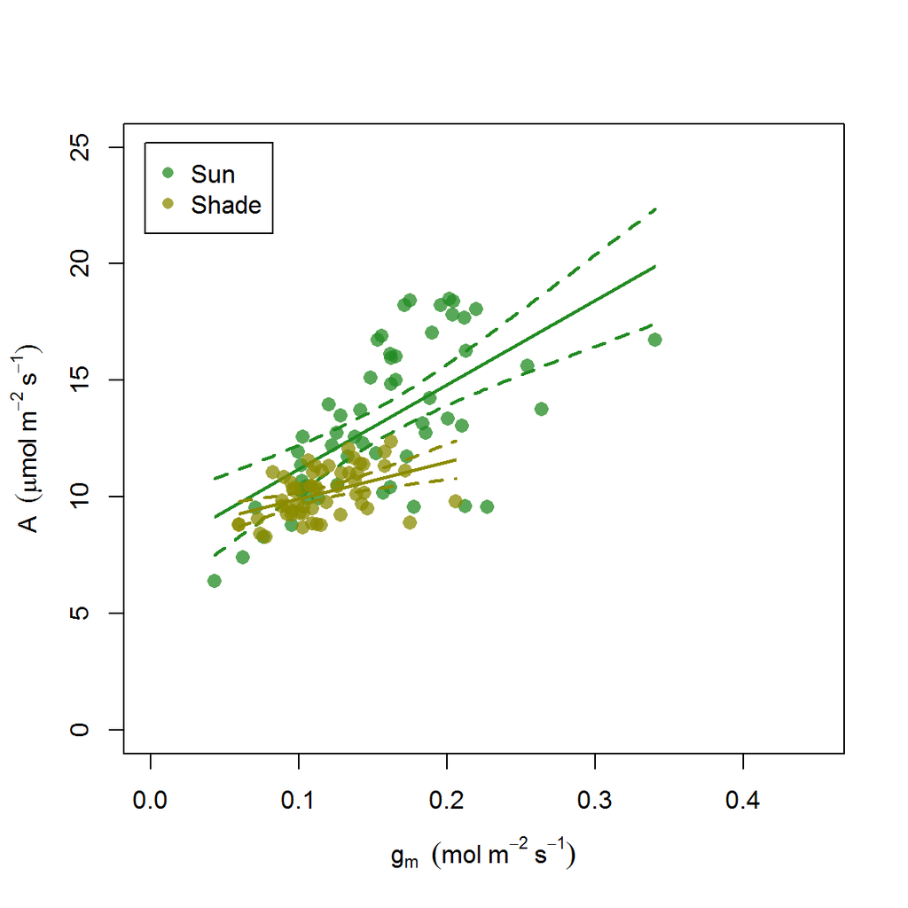

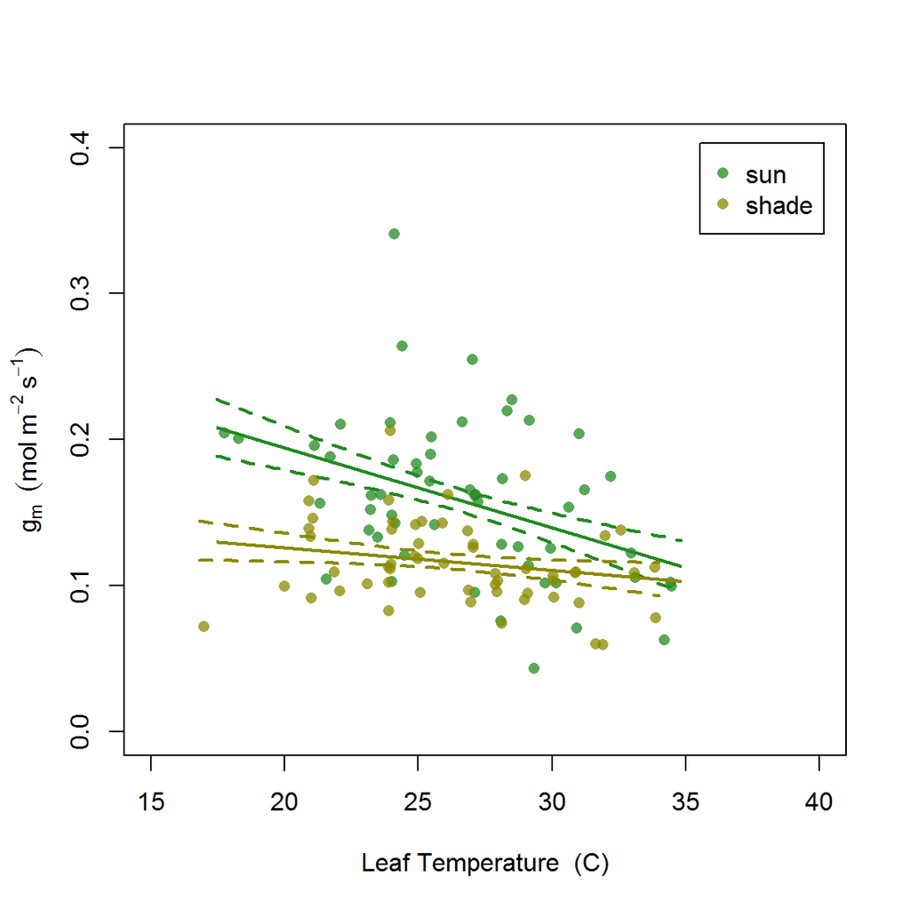

- This figure shows the instantaneous response of gm in shade leaves when the lights are ‘turned on’

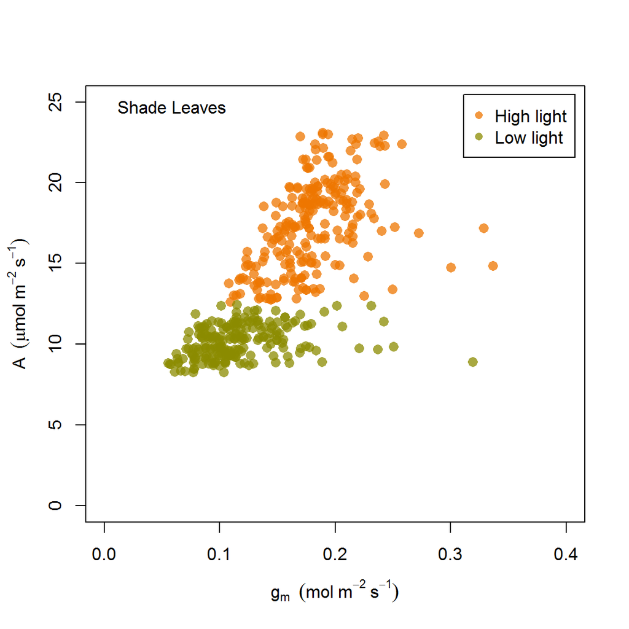